# ETC5521 Exploratory data analysis: Assignment 1

INSTRUCTIONS AND SOLLUTIONS ARE NOT TO BE SHARED

Author

Prof. Di Cook

Published

August 10, 2023

## 🎯 Goal

The assignment is designed to assess your knowledge of the foundation of EDA, distinctions between EDA and IDA, and ability to construct null samples for a particular problem. The assignment represents 25% of your final grade for ETC5521. This is an **individual** assignment.

## 🔧 Preparation

1. Accept the GitHub Classroom Assignment [here](https://classroom.github.com/a/JnXjiHm0) using a GitHub Classroom compatible web browser (e.g. Chrome or Firefox; Safari gets stuck when accepting the assignment so do not use Safari). This should generate a **private** GitHub repository that can be found at https://github.com/etc5521-2023. Your GitHub assignment 1 repo should contain the file `assign01.html`, `README.md`, `Q1.qmd`, `Q2.qmd`, `Q3.qmd`, `Q4.qmd`, `Q5.qmd`, `cafe.rda`, `etc5521-assignment1.Rproj`, `sample_AI_script.md` and `.gitignore`.
2. Answer each question in the corresponding `qmd` in the repo, e.g. for Question 1 write your answer in Q1.
3. For the final submission knit `index.qmd` which will contain your answers from `Q1.qmd`, `Q2.qmd`, `Q3.qmd`, `Q4.qmd` and `Q5.qmd`. You will also need to **upload the script of any Generative AI conversation** you employed in arriving at your solution. *Note that marks are allocated for overall grammar and structure of your final report.*
4. We will check your git commit history. You should have contributions to the repo with consistent commits over time.
5. Refer back to relevant lecture notes and tutorial exercises in developing your solutions. You are expected to **develop your solutions by yourself**, without discussing any details with other class members or other friends or contacts. You can ask for clarifications from the teaching team and we encourage you to attend consultations to get assistance as needed. As a Monash student you are expected to adhere to **[Monash’s academic integrity policy](https://publicpolicydms.monash.edu/Monash/documents/1935748).** and the details on use of Generative AI as detailed on this unit’s Moodle assessment overview.

Deadlines:

| Due date | Turn in | Points |
| --- | --- | --- |
| 4:30pm Fri Aug 11 | Assignment 1 Repo on GitHub has been created | 5 |
| 4:30pm Fri Aug 25 | Final solutions available on repo | 95 |

## 💻 Exercises

1. The [blog post by Manuel Rademaker](https://www.manuel-rademaker.com/blog/tidy_tuesday/2021_05_15_ceo_depatures/) describes a neat analysis of the [Tidy Tuesday](https://github.com/rfordatascience/tidytuesday) data on CEO departures. Re-run this analysis for yourself. Report any problems reproducing the results. Your primary task for this exercise is to outline all of the parts of the analysis, and label them as EDA, IDA or confirmatory analysis.
2. A small cafe in the city of Melbourne is interested in determining whether the daily earnings depend on the weather. They compiled data for a period over 2000-2001 to study this question. Their data is provided in the file `cafe.rda`. It has the following variables:

| var | description |
| --- | --- |
| dt | Date |
| wday | Day of the week |
| revenue | Daily revenue in hundreds, 11=1100 |
| expend | Daily expenses in hundreds |
| precip | Precipitation in mm |
| mint | Minimum temperature, Celsius |
| maxt | Maximum temperature, Celsius |
| source | Source of the weather data |

You need to conduct an **initial data analysis** to find and **report problems** that need to be fixed.

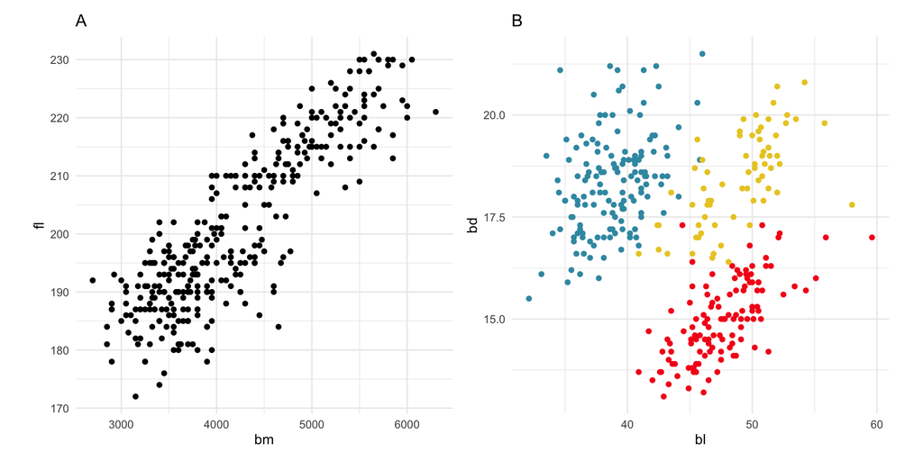

3. Construct a lineup of size 20 for plot A, that will enable assessing the strength of the linear relationship between `bm` and `fl`. Write down what is the null hypothesis, and how you have computed the null samples.
4. Construct a lineup of size 20 for plot B, that will enable assessing the strength of the clustering of the three species. Write down what is the null hypothesis, and how you have computed the null samples.
5. Show your lineups to 8 friends, **individually**, who are not taking this unit, and ask them to choose the most different plot, and to explain to you why they have made that choice. Compute and report the $p$-value, and summarise the reasons that your friends made. (You need to show this to each friend individually so that you get an independent evaluation of the plot.)

## 🧠 Generative AI analysis

In this part, we would like you to actively discuss how generative AI helped with your answers to the assignment questions, and where or how it was mistaken or misleading.

You need to provide the full script of your conversation with any generative AI tool. You do not need to use a paid service, as the freely available systems will also be helpful.

## 📝 Marks

| Part | Points |
| --- | --- |
| GitHub Repo | 5 |
| Q1-Q5 each worth | 15 |
| Generative AI Analysis | 10 |
| Formatting, Spelling & Grammar | 10 |